# Markov Chain Monte Carlo

24 Oct 2016

## Setup

```r
mu <- 15
alpha <- sample(seq(2, 10, 2)) - 6
sigmaeps <- 2
x <- data.frame(lab = factor(rep(1:5, each = 5)))
x$y <- rnorm(25, mu + alpha[x$lab], sigmaeps)
```

```r
source("Gibbs.R")
library("microbenchmark")
library("compiler")
library("profvis")
```

Source R code

## Benchmarking

```r
tmp <- microbenchmark(
 gibbs(0, rep(0, 5), x, t = 400)
)
```

```
Unit: milliseconds
  expr   min    lq  mean median    uq   max neval
 gibbs 9.711 10.08 11.09   10.9 11.35 44.92   100
```

## Profiling

```r
profvis(gibbs(0, rep(0, 5), x, t = 40000))
```

The result shows up in RStudio when you run the code locally.

## Benchmarking

From the profiling information we conclude that the `gibbsstep` function performs of lot of work. Some is redundant. The `gibbsfast` function tries to avoid redundant computations.

```r
tmp <- microbenchmark(
 gibbs(0, rep(0, 5), x, t = 400),
 gibbsfast(0, rep(0, 5), x, t = 400)
)
```

```
Unit: milliseconds
      expr   min    lq  mean median     uq    max neval cld
     gibbs 9.751 9.928 10.67 11.082 11.236 11.890   100   b
 gibbsfast 4.498 4.602  5.28  4.845  5.953  6.903   100  a
```

## Profiling

```r
profvis(gibbsfast(0, rep(0, 5), x, t = 40000))
```

The result reveals that that most time was spent in `rnorm`.

## Benchmarking

The `gibbsfastest` function only calls `rnorm` once to generate all random variables.

```r
tmp <- microbenchmark(
 gibbs(0, rep(0, 5), x, t = 400),
 gibbsfast(0, rep(0, 5), x, t = 400),
 gibbsfastest(0, rep(0, 5), x, t = 400)
)
```

```
    min    lq   mean median     uq    max neval cld
1 9.646 9.901 10.629 10.880 11.228 12.086   100   c
2 4.383 4.581  5.701  5.646  5.984 42.456   100  b
3 2.965 3.147  3.340  3.233  3.385  4.993   100 a
```

This did improve the speed further.

## Byte code compilation

```r
## Compiling functions
gibbsstep <- cmpfun(gibbsstep)
gibbscmp <- cmpfun(gibbs)
gibbsfastestcmp <- cmpfun(gibbsfastest)
```

[output not shown]

Compiling the R code using the compiler package did only speed up the code a little.

## Restructuring code

The process of optimization resulted in one function, which is not very readable, modular or general.

Some modularity can be achieved by passing a lot of different arguments around from one function call to the other.

Using an object oriented approach is an alternative.

In the GibbsObject.R file the fast algorithm is reimplemented in an S3 object oriented way.

## The object oriented implementation

The idea is that first a model object is constructed using the `mixedmodel` function, which takes care of all necessary precomputations. Then the Gibbs sampler is invoked on the object by a call to the `gibbs` function.

```r
## Compiling code from source file
cmpfile("GibbsObject.R")
loadcmp("GibbsObject.Rc")
```

```r
model <- mixedmodel(x, rep(0, 6))
model <- gibbs(model)
```

We can always make a new run of the Gibbs sampler by calling it again.

```r
model <- gibbs(model)
```

## Benchmarking object R code

```r
tmp <- microbenchmark(
 gibbsfastestcmp(0, rep(0, 5), x, t = 400),
 {
   tmp <- mixedmodel(x, rep(0, 6))
   gibbs(tmp, t = 400)
 }
)
```

```
             expr   min    lq  mean median    uq   max neval cld
1 gibbsfastestcmp 2.639 2.774 2.958  2.848 2.973 5.765   100  a
2     gibbsobject 4.233 4.457 4.697  4.566 4.745 6.898   100   b
```

Restructuring the code in the object oriented framework had a price in term of execution time. The profiler can help reveal where the extra time was spent.

## Profiling

The uncompiled code is needed for `profvis` to be informative.

```r
source("GibbsObject.R")
profvis(
  {
    tmp <- mixmodel(x, rep(0, 6))
    gibbs(tmp, t = 40000)
  }
  )
```

Inspecting the profiling information reveals that the update steps take a little longer each (the anonymous funtion) and some extra time was spent in the for loop calling the step function.

## Benefits of the object oriented approach

We can implement methods for plotting and summarizing the results from the Gibbs sampler.

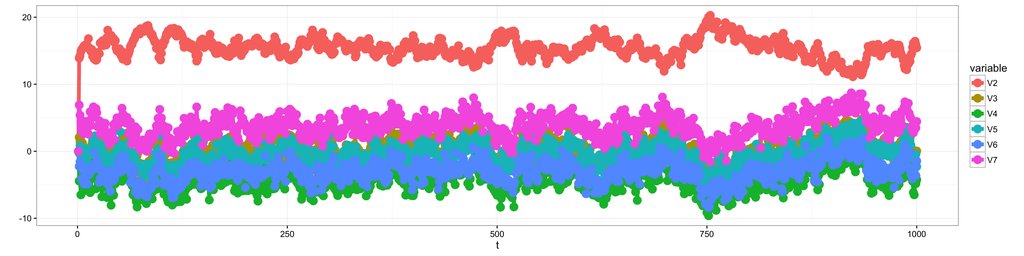

```r
plot(model)
```

## Benefits of the object oriented approach

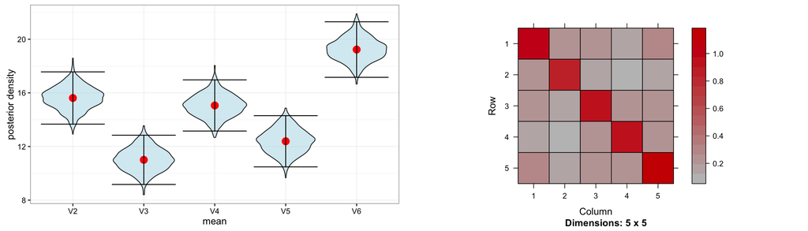

```r
summary(model)
```

## Benefits of the object oriented approach

The `summary` produces in addition to the plot a print of posterior means and standard deviations (of the posterior) and the posterior correlation matrix between the parameters.

```
   Mean est. Stand. err.   V2   V3   V4    V5    V6
V2    15.617       0.994 1.00 0.22 0.23 0.190 0.314
V3    11.006       0.937 0.22 1.00 0.20 0.133 0.189
V4    15.061       0.973 0.23 0.20 1.00 0.223 0.238
V5    12.392       0.974 0.19 0.13 0.22 1.000 0.249
V6    19.231       1.056 0.31 0.19 0.24 0.249 1.000
```

## Some conclusions

Performance of implementations is very much an experimental science.

When comparing two or more implementations *be careful to check that they compute the same (or equivalent) things*. A slow but correct implementation is better than a fast wrong one!

The objected oriented implementation has some benefits. I could write just one new function for creating a `mixmodel` object using "hierachical centering" or any other paramatrization I like. Then all the other functions will work on that object as well.